# Importing and Searching SPSS Files

Simon J. Kiss

28/12/2020

SPSS is a widely used bit of statistical software that is a little bit like Microsoft Excel; it is heavily dependent on a Graphical User Interface (GUI). Because it’s so widely used, a lot of data files are made available in SPSS format. It offers one useful feature which is *labelled* data. This document explores what labelled data look like and how to use them.

The best way to import SPSS files into R is with the `haven` and `labelled` packages.

```r
#install.packages('haven')
#install.packages("labelled")
library(haven)
library(labelled)
```

The file we’re going to play with is in the subfolder `spss/data` in the Chapter 2 folder.

Variable labels and value labels

```r
getwd()
```

And if you look in the `spss/data` subfolder you should see this:

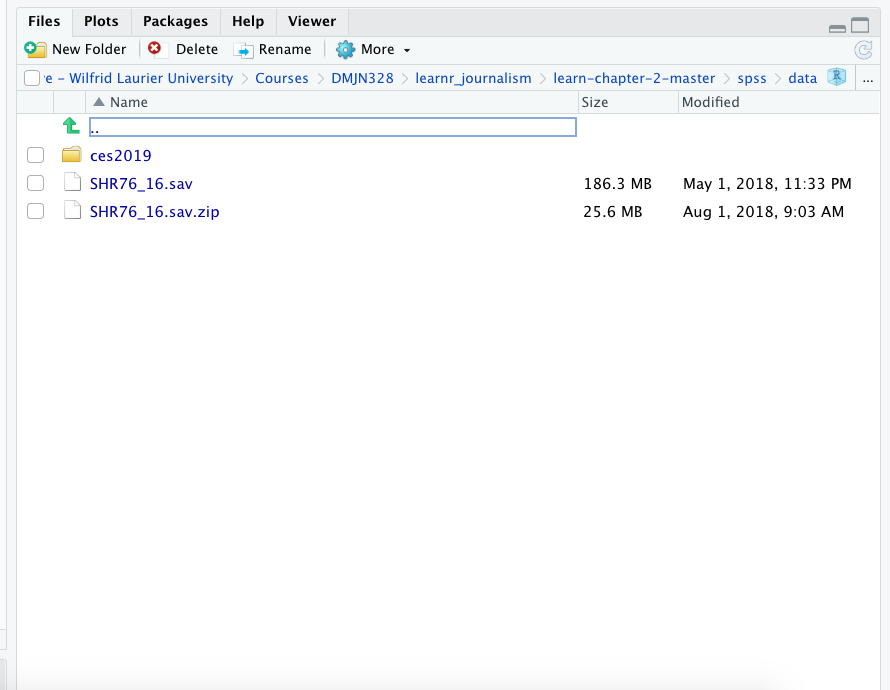

If you open up the `CES2019` folder you should see an SPSS file and a pdf file. The PDF file is the technical workbook for the 2019 Canada Election Study and it includes a lot of useful things you might need to know, including all the texts of the survey questions that were asked. However it can be unwieldy to read through an entire pdf that is a separate file like that. The `haven` package provides some functionality that helps sort through this.

The `.sav` file is the SPSS data file for the 2019 file. To read an SPSS data file in you use the `read_sav()` command with the file path.

```r
ces<-read_sav("spss/data/ces2019/ces2019.sav")
```

If we just take the the variable`q3`, and look at it:

```r
ces$q3
```

```
## <labelled<double>[4021]>: Gender
##   [1] 1 1 1 1 1 1 1 1 1 1 1 1 1 1 2 2 1 2 1 1 1 1 1 1 2 1 2 2 1 2 2 2 2 2 2 1 1
##  [38] 2 1 1 1 1 1 2 1 2 2 1 2 1 1 1 2 1 1 1 2 2 1 1 2 1 2 1 2 2 2 2 1 1 2 2 1 2
##  [75] 2 1 2 1 1 1 1 2 1 1 1 1 2 2 1 2 2 1 1 2 1 2 1 1 2 1
##  [ reached getOption("max.print") -- omitted 3921 entries ]
##
## Labels:
##  value           label
##     -9 (-9) Don't know
##     -8    (-8) Refused
##     -7    (-7) Skipped
##      1        (1) Male
##      2      (2) Female
##      3       (3) Other
```

You can see that it is a 1s and 2s. But we don’t know what those refer to. Labelled data have two sets of attributes: a variable label and a value label. The variable label can be anything, but it often is a description of what the variable is trying to measure.

If we check the variable label of q3 we find this:

```r
var_label(ces$q3)
```

```
## [1] "Gender"
```

OK, so, `q3` is the respondent’s gender. But what does 1 and 2 refer to? Presumably one is male and another is female, but which is which?

This type of information is stored in the value label.

```r
val_labels(ces$q3)
```

```
## (-9) Don't know    (-8) Refused    (-7) Skipped        (1) Male      (2) Female
##              -9              -8              -7               1               2
##       (3) Other
##               3
```

Now we know that a 1 is male, and a 2 is female.

So, later we will be able to recode this into something useful turning the 1 into `Male` and 2 into `female`. There are numerous ways to do this.

The other thing that is extremely useful is the `look_for` function in the `labelled` package. It searches for keywords through all the variables in the data set so that you can get a sense of what variables you have.

```r
look_for(ces, "vote")
```

```
##     variable                                                       label
## 37       q10   Are you certain to vote, likely to vote, unlikely to vote
## 38       q11                     Which party will you likely to vote for
## 39    q11_70                                    If you decide to vote...
## 88       q59 Did you happen to vote in the last Federal election in 2015
## 89       q60                                Which party did you vote for
## 90    q60_70                                Which party did you vote for
## 162     vote                 Party respondent will/might/has vote(d) for
## 169       p2                                      Did you vote in the...
## 170       p3                             Which party did you vote for...
## 171    p3_70                                Which party did you vote for
```

```r
look_for(ces, "education")
```

```
##    variable                                                          label
## 55    q27_a  Should the federal government spend more or less on education
## 93      q61 What is the highest level of education that you have completed
```

```r
look_for(ces, "environment")
```

```
##     variable
## 56     q27_b
## 64       q34
## 217    p29_a
##                                                                            label
## 56           Should the federal government spend more or less on the environment
## 64          Which party do you think would be best at protecting the environment
## 217 Boycotted or bought products for ethical, environmental or political reasons
```

```r
look_for(ces, "age")
```

```
##         variable
## 8   language_CES
## 16  language_PES
## 136          q67
## 137      q67_310
## 146          age
## 147    age_range
## 163       q77eng
## 164        q77fr
## 249        p56_1
## 250        p56_2
## 251        p56_3
## 252        p56_4
## 253        p56_5
## 254        p56_6
```

[output cut: 23 more lines]

```r
look_for(ces, "^age")
```

```
##      variable                                  label
## 146       age       Age (based on year of birth, Q2)
## 147 age_range Age range (based on year of birth, Q2)
```

```r
look_for(ces, "age?")
```

```
##         variable
## 8   language_CES
## 16  language_PES
## 20    weight_CES
## 21    weight_PES
## 51           q22
## 62           q33
## 63        q33_70
## 80           q46
## 136          q67
## 137      q67_310
## 146          age
## 147    age_range
## 158         q22r
## 163       q77eng
```

[output cut: 41 more lines]

```r
look_for(ces, ".age?")
```

```
##         variable
## 8   language_CES
## 16  language_PES
## 51           q22
## 62           q33
## 63        q33_70
## 80           q46
## 136          q67
## 137      q67_310
## 158         q22r
## 163       q77eng
## 164        q77fr
## 182          p14
## 249        p56_1
## 250        p56_2
```

[output cut: 33 more lines]

Now you try searching for different keywords!

```r
look_for(ces, "")
```